# 使用 Hilbert 曲线可视化 CPAN 上 Perl 模块分布

顾祖光

2023-01-09

在网站 http://mapofcpan.org/ 上有一个非常好看的对CPAN Perl模块可视化的例子，如下图：

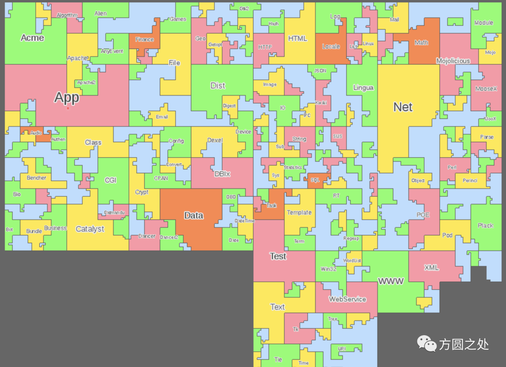

在这篇文章中，我将展示如何使用R包**HilbertCurve**来绘制这样的图。

我们首先读入CPAN上所有模块的名字，这个可以在 https://www.cpan.org/modules/02packages.details.txt 中找到。下面我们直接将这个文件读入：

```r
df = read.table("https://www.cpan.org/modules/02packages.details.txt", skip = 9)
head(df)
```

```
##                     V1    V2                                            V3
## 1            A1z::Html  0.04              C/CE/CEEJAY/A1z-Html-0.04.tar.gz
## 2 A1z::HTML5::Template  0.22    C/CE/CEEJAY/A1z-HTML5-Template-0.22.tar.gz
## 3      A_Third_Package undef           C/CL/CLEMBURG/Test-Unit-0.13.tar.gz
## 4            AAA::Demo undef      J/JW/JWACH/Apache-FastForward-1.1.tar.gz
## 5            AAA::eBay undef      J/JW/JWACH/Apache-FastForward-1.1.tar.gz
## 6                 AAAA undef P/PR/PRBRENAN/Data-Table-Text-20210818.tar.gz
```

模块的名字在第一列中，我们首先将其排序。

```r
all_modules = sort(df[, 1])
```

我们取每个模块的“命名空间”。命名空间是第一个`::`前面的字符串。注意，在Perl中，这可能不叫做命名空间，在这篇文章，为方便起见，我们称之为命名空间。

```r
ns = gsub("::.*$", "", all_modules)
```

现在`ns`是一个字符串向量，下面我们将其中的每一个值对应到一条Hilbert曲线上。我们首次将其转换为一个`Rle`对象。

```r
library(IRanges)
r = Rle(ns)
```

`Rle`是一个很简单的类，定义在**IRanges**包中。在变量`r`中，每一个元素对应着`ns`中一个单独的命名空间，在向量`ns`中，每一个命名空间的位置和长度也被计算出。在下面的代码中，我们提取出这些信息：

```r
s = start(r)          # start position of each ns in r
e = end(r)            # end position of each ns in r
w = width(r)          # width of each ns in r
labels = runValue(r)  # corresponding labels
```

现在我们可以进行Hilbert曲线可视化了。我们将最大的30个命名空间高亮和加上名字。

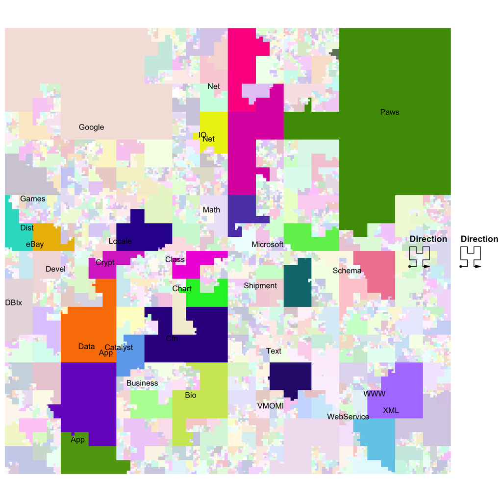

```r
library(HilbertCurve)

ind = order(w, decreasing = TRUE)[1:30]
w_cutoff = w[ ind[30] ]

set.seed(123)  # because we have randomm colors
hc = HilbertCurve(0, length(all_modules), level = 8, mode = "pixel")
hc_layer(hc, x1 = s, x2 = e,
    col = circlize::rand_color(nrun(r), transparency = ifelse(w >= w_cutoff, 0, 0.8)))
hc_text(hc, x1 = s[ind], x2 = e[ind], labels = labels[ind],
    gp = gpar(fontsize = 9))
```

注意，部分文字的位置不是非常好，这以后可以改进。

可能会有人会说，这个其实就是可视化不同类别中软件包的数目，本质上和barplot一样。其实只说对了一半。的确，可视化的信息和barplot是一样的， 但是barplot本质上只是一维上的可视化，而Hilbert曲线是一种”二维“上的可视化技术。如果非要找一种类似的可视化技术，那么应该和Bubble chart比较类似 https://r-graph-gallery.com/circle-packing.html 。

本文使用 [CC BY-NC-SA 4.0](https://creativecommons.org/licenses/by-nc-sa/4.0/deed.zh-hans) 协议发布。